# COMM621 Quantitative Research Methods - Sampling & Statistics

Weiai Wayne Xu curiositybits.cc Department of Communication, UMass-Amherst

2022-02-14

## Samples and sampling distribution

If you recall from reading Charles Wheelan’s *Naked Statistics*, the magic of inferential statistics lies in **the central limit theorem** (The Lebron James of statistics as Wheelan would call it). Based on the theorem, a larger and properly drawn sample will approximate the population data we want to make inference about.

Below we demonstrate the central limit theorem using part of the open data provided by [LA Police Department](https://data.lacity.org/A-Safe-City/Arrest-Data-from-2010-to-Present/yru6-6re4). The dataset contains all arrests made by LAPD in 2016. For simplicity, I included only columns that are relevant to the demo. Read [here](https://data.lacity.org/A-Safe-City/Arrest-Data-from-2010-to-Present/yru6-6re4) for a description of variables.

```r
library(DT)
library(readr)
library(ggplot2)
library(pastecs)
library(sampling)
library(gmodels)
library(data.table)

arrests <- read.csv("https://curiositybits.cc/files/la_arrests_2016.csv")

#show the first 500 arrests
datatable(arrests[1:500,], options = list(pageLength = 5))
```

|  | AREA_DESC | AGE | SEX_CD | DESCENT_CD | GRP_DESC | ARST_TYP_CD | CHARGE | CHRG_DESC | LOCATION |
| --- | --- | --- | --- | --- | --- | --- | --- | --- | --- |
| 1 | 77th Street | 12 | F | B | Other Assaults | M | 243(A)PC | BATTERY ON PERSON | 1300 W 82ND ST |
| 2 | 77th Street | 12 | F | B | Non-Criminal Detention | D | 300(J)WI | PROT CUST/ENDANGER SIBLINGS/UNFIT HOME | 3200 W 59TH PL |
| 3 | 77th Street | 12 | F | B | Non-Criminal Detention | D | 300(J)WI | PROT CUST/ENDANGER SIBLINGS/UNFIT HOME | 7600 S BROADWAY |
| 4 | 77th Street | 13 | F | B | Other Assaults | M | 243(A)PC | BATTERY ON PERSON | 5900 S VERMONT AV |
| 5 | 77th Street | 13 | F | B |  | O | 300(A)WIC |  | 7600 S BROADWAY |
| 6 | 77th Street | 14 | F | B | Prostitution/Allied | M | 653.22(A)PC | LOITER:INTENT:PROSTITUTION | 69TH ST |
| 7 | 77th Street | 15 | F | B | Non-Criminal Detention | D | 300(D)WI | FAIL PROTECT CHILD FROM SEXUAL ABUSE | 7600 S BROADWAY ST |
| 8 | 77th Street | 15 | F | B | Non-Criminal Detention | D | 300(D)WI | FAIL PROTECT CHILD FROM SEXUAL ABUSE | 300 W 79TH ST |
| 9 | 77th Street | 15 | F | B | Robbery | F | 211PC | ROBBERY | 5700 CRENSHAW BL |
| 10 | 77th Street | 15 | F | B | Robbery | F | 211PC | ROBBERY | 5700 CRENSHAW BL |

[output cut: 490 more lines]

```r
#the age info is stored in the AGE column
age <- arrests$AGE
stat.desc(age, basic = F) #show the descriptive stats of age
```

```
##       median         mean      SE.mean CI.mean.0.95          var      std.dev
##   32.0000000   34.9274404    0.0894575    0.1753430  177.8987791   13.3378701
##     coef.var
##    0.3818737
```

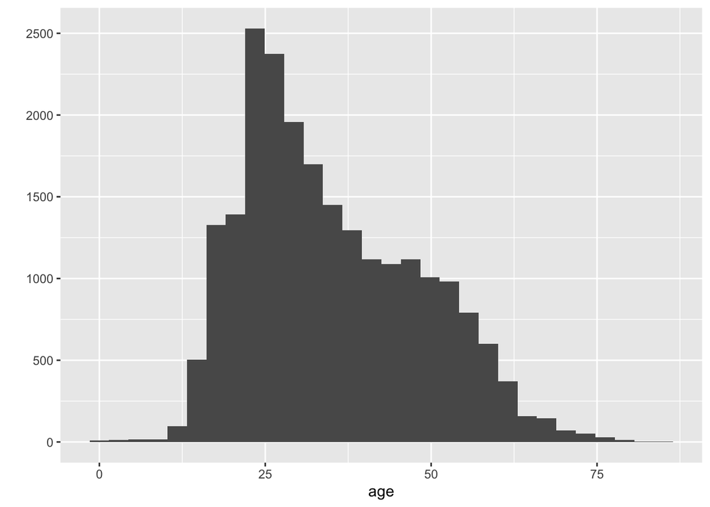

```r
qplot(age, geom="histogram") #make a histogram
```

We will construct a sample of 100 from *age* to see how the sample mean approximates the population mean.

```r
sample1 <- sample(age, 100)
summary(sample1)
```

```
##    Min. 1st Qu.  Median    Mean 3rd Qu.    Max.
##   15.00   22.00   29.50   34.33   45.00   75.00
```

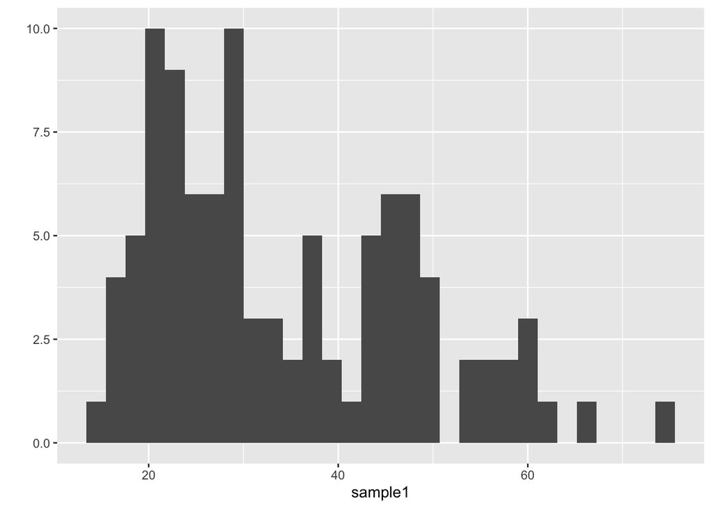

```r
qplot(sample1, geom="histogram")
```

Based on the histogram of *sample1*, the age values are quite dispersed, with notable outliers. Next, we construct a sample of 500 to see if the new sample mean moves closer to the population mean.

```r
sample2 <- sample(age, 500)
summary(sample2)
```

```
##    Min. 1st Qu.  Median    Mean 3rd Qu.    Max.
##    7.00   24.00   32.00   34.75   45.00   76.00
```

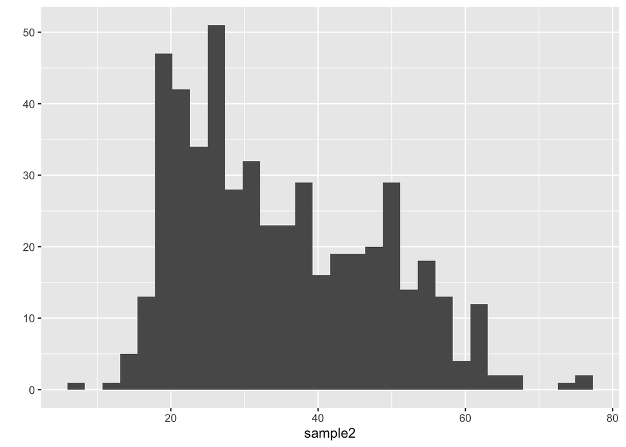

```r
qplot(sample2, geom="histogram")
```

Try a bigger sample. This time we draw 5000 cases.

```r
sample3 <- sample(age, 5000)
summary(sample3)
```

```
##    Min. 1st Qu.  Median    Mean 3rd Qu.    Max.
##    3.00   24.00   32.00   34.61   44.00   80.00
```

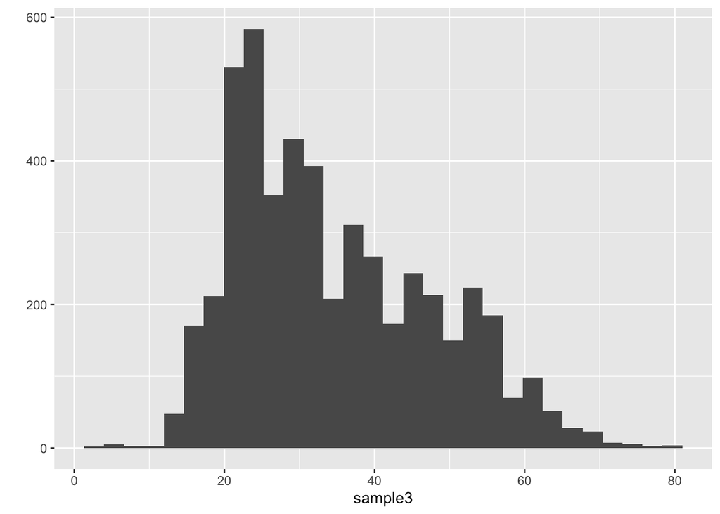

```r
qplot(sample3, geom="histogram")
```

The histogram of *sample3* appears more similar to how the age values are distributed in the population data.

Based on the central limit theorem, if we draw large enough number of samples, the distribution of sample means will approximate the normal distribution (the bell curve), and the larger the sample size, the tighter that distribution will be.

Let’s demonstrate how that plays out in our data. Below we draw 5000 samples with each sample containing 1000 cases. We plot the sample means in the histogram shown below.

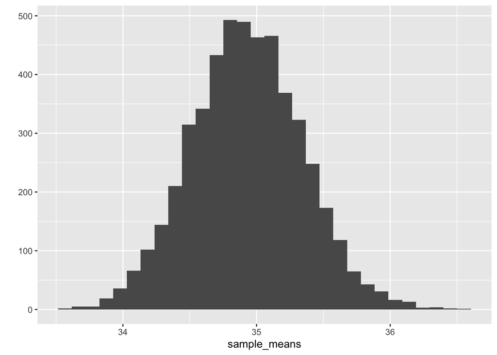

```r
sample_means <- rep(NA, 5000)

for(i in 1:5000){
  samp <- sample(age, 1000)
  sample_means[i] <- mean(samp)
}
qplot(sample_means, geom="histogram")
```

```r
summary(sample_means)
```

```
##    Min. 1st Qu.  Median    Mean 3rd Qu.    Max.
##   33.53   34.65   34.92   34.93   35.20   36.51
```

#Sampling designs

To be able to arrive at generalizable conclusions about the population, we must use properly constructed samples. Below introduces several commonly used sampling designs.

In our case, we have access to the population data (all arrests made in 2016 in LA), so it is fairly easy to produce a random sample. In the code below, we create a sample of 500 cases, without replacement.

```r
randomsample <- arrests[sample(1:nrow(arrests), 500, replace=FALSE),]
knitr::kable(head(randomsample, 5)) #show the first 5 cases
```

|  | AREA_DESC | AGE | SEX_CD | DESCENT_CD | GRP_DESC | ARST_TYP_CD | CHARGE | CHRG_DESC | LOCATION |
| --- | --- | --- | --- | --- | --- | --- | --- | --- | --- |
| 12200 | Newton | 43 | M | H | Liquor Laws | M | 25620BP | OPEN ALCOHOLIC BEV IN PUBLIC PARK/PLACE | PALOMA ST |
| 13875 | Pacific | 42 | F | B | Miscellaneous Other Violations | O | 3454(C)PC | FLASH INCARCERATION | OCEAN FRONT WK |
| 8570 | Hollywood | 53 | M | O | Other Assaults | M | 243(A)PC | BATTERY ON PERSON | 1800 CAHUENGA BL |
| 10866 | N Hollywood | 41 | M | H | Miscellaneous Other Violations | M | 41.24BLAMC | TRESPASS W/PRIOR NOTICE W/I 6 MOS. | 11000 HARTSOOK ST |
| 21674 | West Valley | 72 | M | W | Moving Traffic Violations | F | 2800.2(A)VC | EVADE PO:DISREGARD SAFETY | ETIWANDA |

Take a look at the descriptive stats of the random sample and see how cases are distributed by sex and geographic areas.

```r
mean(randomsample$AGE) #show mean
```

```
## [1] 35.724
```

```r
sd(randomsample$AGE) #show standard deviation
```

```
## [1] 14.07523
```

```r
table(randomsample$SEX_CD) #show frequency count by sex
```

```
##
##   F   M
## 108 392
```

```r
table(randomsample$AREA_DESC) #show frequency count by geographic areas
```

```
##
## 77th Street     Central  Devonshire    Foothill      Harbor  Hollenbeck
##          24          57           7          17          15          12
##   Hollywood     Mission N Hollywood      Newton   Northeast     Olympic
##          45          35          28          29           9          14
##     Pacific     Rampart   Southeast   Southwest     Topanga    Van Nuys
##          39          29          16          32          25          25
##     West LA West Valley    Wilshire
##          14          17          11
```

As you learn from the above sample and the population, the majority of the arrested are male. Also, it is not far-fetched to say that crimes are probably concentrated in certain areas. But, what if we disregard the role of gender and locality and want to generate a sample with equal representation from both sexes and all LA areas?

Below we create a stratified sample based on two separate strata (sex and area). The sex vairable is called **SEX_CD** and geographic area info is stored in **AREA_DESC**.

```r
arrests <- data.table(arrests)
setkey(arrests, AREA_DESC, SEX_CD)

#display # of cases in each strata
knitr::kable(arrests[, .N, keyby = list(AREA_DESC, SEX_CD)])
```

| AREA_DESC | SEX_CD | N |
| --- | --- | --- |
| 77th Street | F | 321 |
| 77th Street | M | 949 |
| Central | F | 716 |
| Central | M | 2308 |
| Devonshire | F | 170 |
| Devonshire | M | 446 |
| Foothill | F | 129 |
| Foothill | M | 569 |
| Harbor | F | 140 |
| Harbor | M | 542 |
| Hollenbeck | F | 103 |
| Hollenbeck | M | 585 |
| Hollywood | F | 397 |
| Hollywood | M | 1718 |
| Mission | F | 263 |
| Mission | M | 848 |
| N Hollywood | F | 254 |
| N Hollywood | M | 801 |
| Newton | F | 166 |
| Newton | M | 888 |
| Northeast | F | 123 |
| Northeast | M | 536 |
| Olympic | F | 130 |
| Olympic | M | 699 |
| Pacific | F | 346 |
| Pacific | M | 1622 |
| Rampart | F | 160 |
| Rampart | M | 762 |
| Southeast | F | 203 |
| Southeast | M | 582 |
| Southwest | F | 236 |
| Southwest | M | 1033 |
| Topanga | F | 178 |
| Topanga | M | 482 |
| Van Nuys | F | 315 |
| Van Nuys | M | 861 |
| West LA | F | 96 |
| West LA | M | 370 |
| West Valley | F | 156 |
| West Valley | M | 471 |
| Wilshire | F | 105 |
| Wilshire | M | 451 |

You will note that there are 42 rows in the above output, meaning there are 42 strata. Run the code below to randomly select 15 cases from each strata. The parameter “srswr” means “simple random sampling with replacement,” which is the method used to select units. Run **?strata()** for the help document.

```r
set.seed(2)
ss <- data.table(strata(arrests, c("AREA_DESC", "SEX_CD"), rep(15, 42), "srswr"))
datatable(ss, options = list(pageLength = 5))
```

|  | AREA_DESC | SEX_CD | ID_unit | Prob | Stratum |
| --- | --- | --- | --- | --- | --- |
| 1 | 77th Street | F | 17 | 0.0457235885584357 | 1 |
| 2 | 77th Street | F | 29 | 0.0457235885584357 | 1 |
| 3 | 77th Street | F | 41 | 0.0457235885584357 | 1 |
| 4 | 77th Street | F | 47 | 0.0457235885584357 | 1 |
| 5 | 77th Street | F | 58 | 0.0457235885584357 | 1 |
| 6 | 77th Street | F | 87 | 0.0457235885584357 | 1 |
| 7 | 77th Street | F | 91 | 0.0457235885584357 | 1 |
| 8 | 77th Street | F | 103 | 0.0457235885584357 | 1 |
| 9 | 77th Street | F | 123 | 0.0457235885584357 | 1 |
| 10 | 77th Street | F | 168 | 0.0457235885584357 | 1 |

[output cut: 620 more lines]

```r
cs <- cluster(arrests, clustername=c("AREA_DESC"),size=5,method="srswor")

#see which areas are selected in the sample and the number of cases in each area
cs <- data.table(cs)
knitr::kable(cs[, .N, keyby = list(AREA_DESC)])
```

| AREA_DESC | N |
| --- | --- |
| Foothill | 698 |
| Harbor | 682 |
| Mission | 1111 |
| N Hollywood | 1055 |
| West LA | 466 |

## Is your statistical significance substantive?

A great myth in social science is **p-value**. It is not an intuitive concept to wrap your head around. Even many scientists struggle to explain it in laymen’s terms, as shown in the video below.

[video not shown]

**What is a p-value?**

We use p-value to indicate statistical significance. The magic number here is .05: a p-value below .05 indicates a statistically significant relationship between variables. It indicates there is a 95% chance that the relationship found in the study sample is NOT due to random chances, and thus the finding from the sample accurately reflects the patterns in the population.

But, even that is an over-extrapolation. Read [this article by FiveThirtyEight](https://fivethirtyeight.com/features/not-even-scientists-can-easily-explain-p-values/).

This is how the article explains p-value:

> So what information can you glean from a p-value? The most straightforward explanation I found came from Stuart Buck, vice president of research integrity at the Laura and John Arnold Foundation. Imagine, he said, that you have a coin that you suspect is weighted toward heads. (Your null hypothesis is then that the coin is fair.) You flip it 100 times and get more heads than tails. The p-value won’t tell you whether the coin is fair, but it will tell you the probability that you’d get at least as many heads as you did if the coin was fair. That’s it — nothing more.

**Putting p-value to test**

We will use a dataset containing the math scores of all students in the New York area. We download the data and name the data frame *math*. The scores are in the *Mean.Scale.Score* column and students’ gender is stored in *Category*.

```r
library(readr)
library(ggplot2)
library(pastecs)
library(sampling)
library(gmodels)
library(dplyr)
library(data.table)

math <- read.csv("https://curiositybits.cc/files/math.csv")

#add a column for row id. We will need the row ids for merging datasets in later steps
math <- mutate(math, ID_unit = rownames(math))
math$ID_unit <- as.integer(math$ID_unit)

# Convert the Category column into a categorical variable
math$Category <- as.factor(math$Category)

#show the first 50 observations
datatable(math[1:50,], options = list(pageLength = 5))
```

|  | DBN | School.Name | Grade | Year | Category | Number.Tested | Mean.Scale.Score | Level1_N | Level1_. | Level2_N | Level2_. | Level3_N | Level3_. | Level4_N | Level4_. | Level3.4_N | Level3.4_. | ID_unit |
| --- | --- | --- | --- | --- | --- | --- | --- | --- | --- | --- | --- | --- | --- | --- | --- | --- | --- | --- |
| 1 | 01M015 | PS 015 ROBERTO CLEMENTE | 3 | 2013 | Female | 12 | 274 | 9 | 75 | 3 | 25 | 0 | 0 | 0 | 0 | 0 | 0 | 1 |
| 2 | 01M015 | PS 015 ROBERTO CLEMENTE | 3 | 2013 | Male | 15 | 281 | 7 | 46.7 | 8 | 53.3 | 0 | 0 | 0 | 0 | 0 | 0 | 2 |
| 3 | 01M015 | PS 015 ROBERTO CLEMENTE | 3 | 2015 | Female | 7 | 297 | 3 | 42.9 | 1 | 14.3 | 2 | 28.6 | 1 | 14.3 | 3 | 42.9 | 3 |
| 4 | 01M015 | PS 015 ROBERTO CLEMENTE | 3 | 2015 | Male | 10 | 268 | 7 | 70 | 3 | 30 | 0 | 0 | 0 | 0 | 0 | 0 | 4 |
| 5 | 01M015 | PS 015 ROBERTO CLEMENTE | 3 | 2017 | Female | 14 | 299 | 5 | 35.7 | 4 | 28.6 | 3 | 21.4 | 2 | 14.3 | 5 | 35.7 | 5 |
| 6 | 01M015 | PS 015 ROBERTO CLEMENTE | 3 | 2017 | Male | 15 | 304 | 3 | 20 | 5 | 33.3 | 4 | 26.7 | 3 | 20 | 7 | 46.7 | 6 |
| 7 | 01M015 | PS 015 ROBERTO CLEMENTE | 4 | 2013 | Female | 12 | 269 | 9 | 75 | 3 | 25 | 0 | 0 | 0 | 0 | 0 | 0 | 7 |
| 8 | 01M015 | PS 015 ROBERTO CLEMENTE | 4 | 2013 | Male | 8 | 290 | 3 | 37.5 | 3 | 37.5 | 1 | 12.5 | 1 | 12.5 | 2 | 25 | 8 |
| 9 | 01M015 | PS 015 ROBERTO CLEMENTE | 4 | 2014 | Female | 9 | 285 | 5 | 55.6 | 3 | 33.3 | 1 | 11.1 | 0 | 0 | 1 | 11.1 | 9 |
| 10 | 01M015 | PS 015 ROBERTO CLEMENTE | 4 | 2014 | Male | 15 | 281 | 4 | 26.7 | 11 | 73.3 | 0 | 0 | 0 | 0 | 0 | 0 | 10 |

[output cut: 40 more lines]

Since this dataset can be treated as the population data, we know exactly how female and male students differ in math scores. Run the code below to see the mean difference. Female student do slightly better than male student. But the difference isn’t that big (<2).

```r
aggregate(math$Mean.Scale.Score,by=list(Gender=math$Category), mean)
```

```
##   Gender        x
## 1 Female 300.2872
## 2   Male 298.7334
```

In most research scenarios, we don’t have access to the population data and thus have to resort to sampling. Next, we draw a random sample of 100, compare means across groups, and make inference about the population using this sample. Because this is a by group comparison, we will use a simple t-test.

```r
sample1 <- sample_n(math, 100)
t.test(Mean.Scale.Score ~ Category,data=sample1)
```

```
##
##  Welch Two Sample t-test
##
## data:  Mean.Scale.Score by Category
## t = 0.47256, df = 92.884, p-value = 0.6376
## alternative hypothesis: true difference in means between group Female and group Male is not equal to 0
## 95 percent confidence interval:
##  -6.804814 11.054814
## sample estimates:
## mean in group Female   mean in group Male
##              298.000              295.875
```

*What is the p-value of the above t-test? Is it statistically significant?*

Let run a test using a bigger sample (n=1000). Is the test statistically significant this time?

```r
sample2 <- sample_n(math, 1000)
t.test(Mean.Scale.Score ~ Category,data=sample2)
```

```
##
##  Welch Two Sample t-test
##
## data:  Mean.Scale.Score by Category
## t = 2.7004, df = 997.96, p-value = 0.007043
## alternative hypothesis: true difference in means between group Female and group Male is not equal to 0
## 95 percent confidence interval:
##  1.019974 6.443928
## sample estimates:
## mean in group Female   mean in group Male
##             301.6129             297.8810
```

Try a even bigger sample (n=5000)

```r
sample3 <- sample_n(math, 5000)
t.test(Mean.Scale.Score ~ Category,data=sample3)
```

```
##
##  Welch Two Sample t-test
##
## data:  Mean.Scale.Score by Category
## t = 3.1245, df = 4989.6, p-value = 0.001791
## alternative hypothesis: true difference in means between group Female and group Male is not equal to 0
## 95 percent confidence interval:
##  0.7180859 3.1367301
## sample estimates:
## mean in group Female   mean in group Male
##             300.2618             298.3344
```

Very likely, you will see a significant difference in a large sample. A rule of thumb is that all else constant, you will more likely find significant findings when using larger samples.

In our case, with a sample of 5000, even very tiny differences in math scores become detectable. **But is the difference meaningful?** In other words, does statistical significance mean substantive significance? It *does not*.

A p-value says nothing about the “strength of association,” or the meaningfulness of difference. Yes, females have better math scores than males, but the difference in the sample and the population is negligible–it will be absurd to talk about a substantive gap in mathematical skills when male and female students are just a few points apart.

**The takeaway? Statistical significance ≠ substantive significance.**

Some social scientists are accused of engaging in p-hacking to inflate their scholarly contribution. Sometimes, when they have trouble finding significant results, they are tempted to try a bigger sample without thinking about whether a significant, but tiny difference between groups is truly meaningful. There is [an entire episode](https://youtu.be/0Rnq1NpHdmw) on *Last Week Tonight with John Oliver* dedicated to uncovering p-hacking.

A work by [Weiai Wayne Xu](https://github.com/weiaiwayne/)

*curiositybits.cc*